# Occupational Lung Disease

Carl Reynolds / @drcjar / www.carlreynolds.net

15 August 2016

# Today you will learn

1. That people take their lungs to work
2. That there are occupational lung disease in the UK
3. That not all asthma at work is occupational asthma
4. ?Why drug reps aren't your friend
5. ?How I made this presentation (computer things)
6. ?Is occupational asbestos exposure an underecognised cause of IPF (my PhD)

# Lungs at work

> "The air must be pure, habitable, and bright, It should be neither contaminated nor smell of the sewer"

Regimen Sanitatis Salernitanum

# The old diseases haven't gone away and there are new ones

> In 2014/15, 464,000 working days were lost due to work-related breathing or lung problems (95% confidence interval: 188,000 – 739,000)

http://www.hse.gov.uk/statistics/tables/swit1.xlsx

> There are currently approximately 12,000 deaths each year due to occupational respiratory diseases, about two-thirds of which were due to asbestos-related diseases or COPD.

www.hse.gov.uk/statistics/causdis/respiratory-diseases/

# Lung diseases caused by workplace exposures

- Asthma (about 15% of total)
- COPD (about 15% of total)
- Bronchiolitis obliterans
- Organising pneumonia
- ILD (HP, pneumoconiosis, berrylliosis, hard metal disease)
- Lung cancer (IARC keeps a list that includes diesel fume) and mesothelioma

# Lung diseases made worse by workplace exposures

- Asthma
- COPD
- ILD
- Cancer

# Attribution

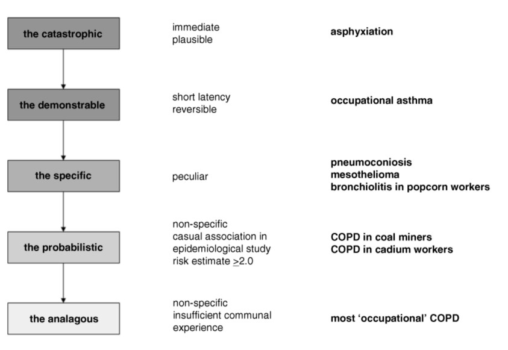

Hierarchy of attribution

# Outbreaks

- Ardystil syndrome
- Humidifier disinfectant-associated interstitial lung disease
- Metal fluid workers lung disease

# Work-related asthma

# 'OA' is a 37 year old supermarket worker with breathlessness

- 'OA' Presented to A&E with a 2/7 history of increasing SOB
- Wheeze and non-productive cough. No chest pain / night sweats / fevers. Never smoker.
- No previous medical history, no regular medications. O/E tachypnoea, diffuse expiatory wheeze, PEFR 380 (70% predicted)
- CXR and bloods unremarkable

# A working diagnosis of asthma

- Oxygen, salbutamol and ipratropium bromide nebs
- Steroids
- Careful observation
- Better by day 3 and discharged with salbutamol inhaler and respiratory clinic f/u

# What's missing?

- An occupational history is missing
- What do you do and use in your job? (relevant exposures?)
- How long have you been there?
- Are your symptoms better when away from work?
- Are other people at work similarly unwell?

# Could it be occupational?

# Yes it could be. Certainly sounds work related.

- OA has worked as at Tesco since she was 16. 6 years ago she moved from working on the checkouts to working in the bakery.
- OA makes the bread in a dusty enviornment with lots of flour. For the past several months she has had nasal congestion, cough, and wheeze.
- She feels better on the weekends and her symptoms almost completely went away when she went to Ibiza on holiday for 2/52.

# Occupational asthma

- There are many asthmagens
- There are many things to be done
- There are many reasons to refer to a specialist

# Work exacerbated asthma

- The prognosis is different
- The managment is different
- There are many reasons to refer to a specialist

# Occupational asthma

- Sensitizer-induced
- Irritant-induced e.g Reactive Airways Dysfunction Syndrome (RADS)

# A consensus definition

> Form of work-related asthma characterized by variable airflow obstruction, airway hyper responsiveness, and airway inflammation attributable to a particular exposure in the workplace and not due to stimuli encountered outside the workplace

Tarlo et al. Diagnosis and management of work-related asthma: American College Of Chest Physicians Consensus Statement Chest. 2008;134(3 Suppl):1S.2.

# Sensitizers

- HMW agents (>5-10kD) act as sensitizing antigens e.g animal and plant proteins and polysaccharides such as flour, proteins in animal urine, and enzymes
- LMW agents, are haptens (incomplete antigens) e.g disocyanates (nb cyanate group is RN=C=O) used in polythene and plastics production, spray painting, foam coat manufacture, and adhesive/sealant production use wood dusts e.g western red cedar, persulfate salts e.g K2S2O8 used in hair dye

# Why refer?

- accurate diagnosis is important
- specialist tests, expertise, familiarity
- management (and prognosis) differs depending on diagnosis

# What happens in the clinic

- full occupational history
- skin prick testing, spirometry, peak flow diary
- site visits
- bronchoprovocation testing
- discussion of what to do next

# References

1. Feary, Johanna, Hilary Pinnock, and Paul Cullinan. Occupational asthma. BMJ 353 (2016): i2658.
2. Occupational and Environmental Lung Diseases: Diseases from Work, Home, Outdoor and Other Exposures. Susan Tarlo (Editor), Paul Cullinan (Editor), Benoit Nemery (Editor).
3. A Clinical Guide to Occupational and Environmental Lung Diseases. Editors: Huang, Yuh-Chin T., Ghio, Andrew J., Maier, Lisa A. (Eds.)